# Python lab: convexity and unconstrained optimization

Course package · Download complete lab ZIP

Extract the ZIP. Keep skh_palette.py beside the notebook. Open NLP1-guided-lab.ipynb in Jupyter and run from top to bottom. The executed reference contains expected results. Install NumPy, SciPy, and Matplotlib in your own Python environment if needed.

Core lab in class: steps 1–4 and 7–8. Use steps 5–6 and 9–10 for further exploration or follow-up. Predict each result before opening the expected output.

Download notebook · Executed reference notebook · Python script

## 1. Setup and prediction

Use a kernel with NumPy, SciPy, and Matplotlib. Keep skh_palette.py beside this notebook, or use the lab ZIP. Predict the objective and gradient at [3,0] before running.

```
import numpy as np
import matplotlib.pyplot as plt
from scipy.optimize import minimize
import skh_palette as skh
skh.use()
C = skh.C
np.set_printoptions(precision=8, suppress=True)

def f(x):
    u, v = np.asarray(x, dtype=float)
    return (u - 1)**2 + 4*(v + 2)**2

def grad(x):
    u, v = np.asarray(x, dtype=float)
    return np.array([2*(u - 1), 8*(v + 2)])

def hess(x):
    return np.diag([2.0, 8.0])

x0 = np.array([3.0, 0.0])
xstar = np.array([1.0, -2.0])
print("f(x0) =", f(x0))
print("gradient =", grad(x0))
print("Hessian =\n", hess(x0))
assert f(x0) == 20
np.testing.assert_allclose(grad(x0), [4,16])
np.testing.assert_allclose(np.linalg.eigvalsh(hess(x0)), [2,8])
```

**Expected output and interpretation**

```
f(x0) = 20.0
gradient = [ 4. 16.]
Hessian =
 [[2. 0.]
 [0. 8.]]
```

## 2. Derivative checks

Central differences provide a local numerical check. They do not prove that the formula is correct everywhere. Compare at two different points.

```
def fd_gradient(fun, x, eps=1e-6):
    eye = np.eye(len(x))
    return np.array([(fun(x+eps*d)-fun(x-eps*d))/(2*eps) for d in eye])

def fd_hessian(gradient, x, eps=1e-6):
    eye = np.eye(len(x))
    return np.column_stack([(gradient(x+eps*d)-gradient(x-eps*d))/(2*eps) for d in eye])

for x in [x0, np.array([-0.7, 1.2])]:
    ge = np.linalg.norm(fd_gradient(f,x)-grad(x))
    he = np.linalg.norm(fd_hessian(grad,x)-hess(x))
    print("x =", x, "gradient error =", ge, "Hessian error =", he)
    assert ge < 1e-6 and he < 1e-6
```

**Expected output and interpretation**

```
x = [3. 0.] gradient error = 7.240783595275675e-10 Hessian error = 3.6203917976378373e-10
x = [-0.7  1.2] gradient error = 2.8912489481417967e-09 Hessian error = 6.783880754341179e-10
```

## 3. Two steps by hand and in Python

Use alpha=0.1. Predict both iterates and objective values before running.

```
alpha = 0.1
x1 = x0-alpha*grad(x0)
x2 = x1-alpha*grad(x1)
for k,x in enumerate([x0,x1,x2]):
    print(k, "x =", x, "f =", f(x), "g =", grad(x))
np.testing.assert_allclose(x1,[2.6,-1.6])
np.testing.assert_allclose(x2,[2.28,-1.92])
np.testing.assert_allclose([f(x0),f(x1),f(x2)],[20,3.2,1.664])
```

**Expected output and interpretation**

```
0 x = [3. 0.] f = 20.0 g = [ 4. 16.]
1 x = [ 2.6 -1.6] f = 3.2 g = [3.2 3.2]
2 x = [ 2.28 -1.92] f = 1.6640000000000008 g = [2.56 0.64]
```

## 4. A reusable fixed-step gradient loop

The reason gradient_tolerance means approximate stationarity. For nonconvex functions it does not certify a minimum. The loop records the last point even when it stops at the iteration limit.

```
def fixed_gd(fun, gradient, initial, alpha, tol=1e-8, maxiter=3000):
    x = np.asarray(initial,dtype=float).copy()
    trace = []
    for k in range(maxiter+1):
        value = float(fun(x))
        g = np.asarray(gradient(x),dtype=float)
        norm = float(np.linalg.norm(g))
        trace.append((k, x.copy(), value, norm))
        if not np.isfinite(value) or not np.all(np.isfinite(g)):
            return trace, "nonfinite"
        if norm <= tol:
            return trace, "gradient_tolerance"
        if abs(value)>1e12:
            return trace, "large_objective_guard"
        if k == maxiter:
            return trace, "iteration_limit"
        x = x-alpha*g
    raise RuntimeError("Unreachable")

trace, reason = fixed_gd(f,grad,x0,0.1)
k,x,value,gnorm = trace[-1]
print("reason =", reason, "iterations =", k)
print("x =", x, "f =", value, "gradient norm =", gnorm)
assert reason == "gradient_tolerance"
np.testing.assert_allclose(x,xstar,atol=1e-7)
assert value < 1e-14
```

**Expected output and interpretation**

```
reason = gradient_tolerance iterations = 89
x = [ 1. -2.] f = 2.2494568216133316e-17 gradient norm = 9.485687790800057e-09
```

## 5. Paths and function values

The star marks the exact minimizer. Compare this plot with the first two hand-calculated steps.

```
path = np.array([row[1] for row in trace])
u,v = np.meshgrid(np.linspace(-0.3,3.7,150),np.linspace(-3.9,1,150))
z = (u-1)**2+4*(v+2)**2
fig,axs = plt.subplots(1,2,figsize=(10,4))
axs[0].contour(u,v,z,levels=[0.2,0.5,1,2,4,8,16,24],colors=C['teal'],linewidths=1.5)
axs[0].plot(path[:,0],path[:,1],'-o',color=C['amber'],lw=2,ms=4)
axs[0].plot([1],[-2],'*',color=C['graphite'],ms=12)
axs[0].set(xlabel='u',ylabel='v',title='Gradient descent, alpha=0.1')
axs[1].semilogy([r[0] for r in trace],[max(r[2],1e-30) for r in trace],color=C['teal'],lw=2)
axs[1].set(xlabel='Iteration',ylabel='f(x)-f*',title='Objective error')
plt.tight_layout()
plt.show()
```

**Expected output and interpretation**

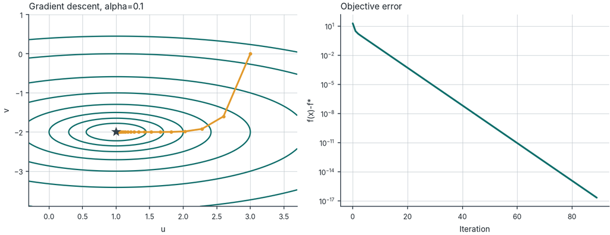

## 6. Fixed step-size experiments

Predict the behavior using the two error multipliers. In particular, distinguish oscillation at alpha=0.25 from growth at alpha=0.30.

```
runs = {}
for alpha in [0.05,0.1,0.24,0.25,0.3]:
    tr,rs = fixed_gd(f,grad,x0,alpha)
    runs[alpha]=(tr,rs)
    k,x,val,gn=tr[-1]
    print(f"alpha={alpha:.2f}  {rs:23s}  k={k:4d}  f={val:.6g}  ||g||={gn:.6g}")
assert runs[0.1][1]=='gradient_tolerance'
assert runs[0.24][1]=='gradient_tolerance'
assert runs[0.25][1]=='iteration_limit'
assert runs[0.3][1]=='large_objective_guard'
np.testing.assert_allclose(runs[0.25][0][-1][2],16,atol=1e-9)

fig,ax=plt.subplots(figsize=(7,4))
for alpha,color,style in [(0.1,C['teal'],'-'),(0.25,C['amber'],'--'),(0.3,C['graphite'],':')]:
    tr=runs[alpha][0][:36]
    ax.semilogy([r[0] for r in tr],[max(r[2],1e-30) for r in tr],color=color,ls=style,lw=2,label=f'alpha={alpha}')
ax.set(xlabel='Iteration',ylabel='f(x)-f*',title='Same starting point for every run')
ax.legend()
plt.tight_layout()
plt.show()
```

**Expected output and interpretation**

```
alpha=0.05  gradient_tolerance       k= 188  f=2.49599e-17  ||g||=9.99199e-09
alpha=0.10  gradient_tolerance       k=  89  f=2.24946e-17  ||g||=9.48569e-09
alpha=0.24  gradient_tolerance       k= 255  f=5.44392e-18  ||g||=9.33288e-09
alpha=0.25  iteration_limit          k=3000  f=16  ||g||=16
alpha=0.30  large_objective_guard    k=  37  f=1.04134e+12  ||g||=4.08185e+06
```

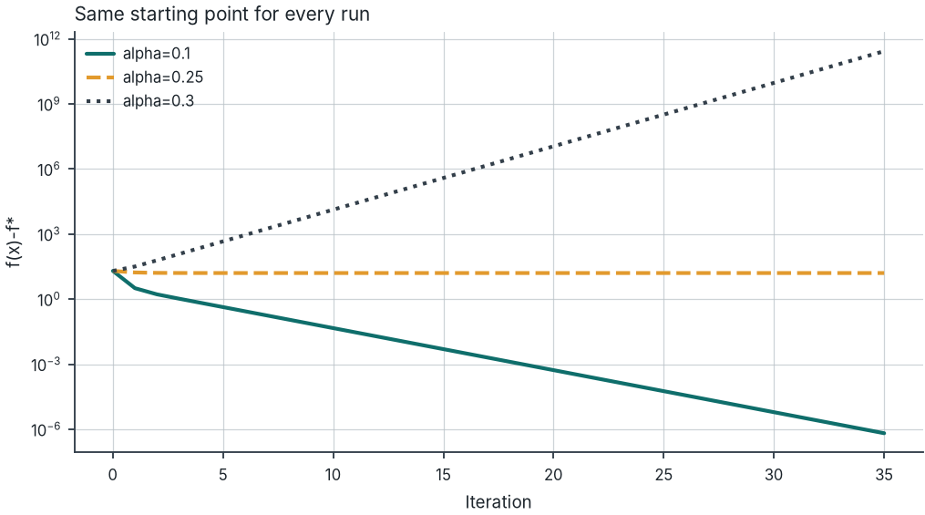

## 7. Newton and a solver reference

Solve H p = -g, rather than explicitly inverting H. The optional SciPy call below uses a trust-region Newton method, so its iteration count need not equal one full Newton step.

```
p = np.linalg.solve(hess(x0),-grad(x0))
xnew = x0+p
print("p =",p, "xnew =",xnew,"f =",f(xnew))
np.testing.assert_allclose(p,[-2,-2])
np.testing.assert_allclose(xnew,xstar)
assert f(xnew)==0

reference = minimize(f,x0,method='trust-exact',jac=grad,hess=hess,options={'gtol':1e-9})
print("SciPy:",reference.success,reference.message)
print("x =",reference.x,"f =",reference.fun,"gradient norm =",np.linalg.norm(grad(reference.x)))
assert reference.success
np.testing.assert_allclose(reference.x,xstar,atol=1e-7)
```

**Expected output and interpretation**

```
p = [-2. -2.] xnew = [ 1. -2.] f = 0.0
SciPy: True Optimization terminated successfully.
x = [ 1. -2.] f = 9.860761315262648e-31 gradient norm = 3.66205343881779e-15
```

## 8. Nonconvex starting points

Use q(x)=(x²-1)², not the two-variable quadratic. Classify the returned stationary point using q double prime and the nonnegative-square lower bound.

```
def q(x):
    t=float(x[0]); return (t*t-1)**2

def qgrad(x):
    t=float(x[0]); return np.array([4*t*(t*t-1)])

def qsecond(t): return 12*t*t-4

for start in [-1.5,-0.2,0,0.2,1.5]:
    tr,rs=fixed_gd(q,qgrad,[start],0.05)
    k,x,val,gn=tr[-1]; curvature=qsecond(x[0])
    kind='strict local minimum' if curvature>0 else 'strict local maximum' if curvature<0 else 'inconclusive'
    print(f"start={start:4.1f} end={x[0]: .8f} f={val:.5g} H={curvature:.5g} {rs}: {kind}")
    if start==0: assert x[0]==0 and val==1 and curvature==-4
    else: assert abs(abs(x[0])-1)<1e-7 and val<1e-14
# At +/-1, q=0 and q is nonnegative everywhere: these minima are global.
```

**Expected output and interpretation**

```
start=-1.5 end=-1.00000000 f=3.6603e-18 H=8 gradient_tolerance: strict local minimum
start=-0.2 end=-1.00000000 f=4.4482e-18 H=8 gradient_tolerance: strict local minimum
start= 0.0 end= 0.00000000 f=1 H=-4 gradient_tolerance: strict local maximum
start= 0.2 end= 1.00000000 f=4.4482e-18 H=8 gradient_tolerance: strict local minimum
start= 1.5 end= 1.00000000 f=3.6603e-18 H=8 gradient_tolerance: strict local minimum
```

## 9. A failed Newton step

Predict the sign of g*p before evaluating the new function value. Negative curvature makes the raw Newton direction an ascent direction here.

```
start=0.2
g0=qgrad([start])[0]
H0=qsecond(start)
p=-g0/H0
new=start+p
print("gradient =",g0,"Hessian =",H0,"direction =",p,"g*p =",g0*p)
print("old x, f:",start,q([start]),"new x, f:",new,q([new]))
np.testing.assert_allclose(new,-1/55)
assert g0*p>0 and q([new])>q([start])
xx=np.linspace(-1.5,1.5,400)
fig,ax=plt.subplots(figsize=(7,4))
ax.plot(xx,(xx**2-1)**2,color=C['teal'],lw=2,label='q(x)')
ax.scatter([start,new],[q([start]),q([new])],color=[C['teal'],C['amber']],s=55)
ax.annotate('Newton step',xy=(new,q([new])),xytext=(-1.2,1.5),arrowprops={'arrowstyle':'->','color':C['graphite']})
ax.set(xlabel='x',ylabel='q(x)',title='A step toward the local maximum')
plt.tight_layout()
plt.show()
```

**Expected output and interpretation**

```
gradient = -0.768 Hessian = -3.52 direction = -0.2181818181818182 g*p = 0.1675636363636364
old x, f: 0.2 0.9216 new x, f: -0.018181818181818188 0.9993389522573595
```

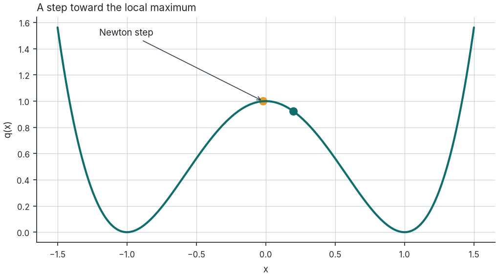

## 10. Independent practice checks

Attempt worksheet A-C before running this cell. Check a coupled Hessian, one nonquadratic Newton step, and the limits of the second-derivative test.

```
H=np.array([[2.,2.],[2.,6.]])
c=np.array([-4.,-8.])
solution=np.linalg.solve(H,-c)
value=0.5*solution@H@solution+c@solution+7
print("Practice A:",solution,"value =",value,"eigenvalues =",np.linalg.eigvalsh(H))
np.testing.assert_allclose(solution,[1,1])
np.testing.assert_allclose(value,1)
np.testing.assert_allclose(np.linalg.eigvalsh(H),[4-2*np.sqrt(2),4+2*np.sqrt(2)])

x=2.; direction=-(4*x**3+2*x)/(12*x*x+2); xnew=x+direction
print("Practice B:","p =",direction,"xnew =",xnew,"value =",xnew**4+xnew*xnew)
np.testing.assert_allclose(xnew,1.28)
np.testing.assert_allclose(xnew**4+xnew*xnew,4.32275456)
print("Practice C: x^4 has a minimum and -x^4 a maximum at 0, although both first and second derivatives vanish there.")
```

**Expected output and interpretation**

```
Practice A: [1. 1.] value = 1.0 eigenvalues = [1.17157288 6.82842712]
Practice B: p = -0.72 xnew = 1.28 value = 4.32275456
Practice C: x^4 has a minimum and -x^4 a maximum at 0, although both first and second derivatives vanish there.
```

Reference: [SciPy minimize documentation](https://docs.scipy.org/doc/scipy/reference/generated/scipy.optimize.minimize.html).